# Maths Grades Analysis

| Name | NetID |
| --- | --- |
| Annabelle Griffith-Topps | griffithtopp |
| Jake White | jtwhite4 |
| Bryan Li | bli378 |
| Ana Klabjan | aklabjan |
| Zi Hern Wong | zwong4 |
| Jacob Larget | jlarget |

# Introduction

Our data set describes 395 students, their math grades for a given semester, recorded on three occasions, as well as generic and consistent demographic information. With this data, we created models to answer two statistical questions: (1) How accurately can we determine whether a student will drop out by the end of the semester based on their demographic information, and (2) How accurately can we determine a student’s final semester grade, given that they did not drop out of school?

```r
data <- read.csv("student-mat.csv")
head(data,3)
```

|  | school | sex | age | address | famsize | Pstatus | Medu | Fedu | Mjob | Fjob | reason | guardian | traveltime | studytime | failures | schoolsup | famsup | paid | activities | nursery | higher | internet | romantic | famrel | freetime | goout | Dalc | Walc | health | … |
| --- | --- | --- | --- | --- | --- | --- | --- | --- | --- | --- | --- | --- | --- | --- | --- | --- | --- | --- | --- | --- | --- | --- | --- | --- | --- | --- | --- | --- | --- | --- |
| 1 | GP | F | 18 | U | GT3 | A | 4 | 4 | at_home | teacher | course | mother | 2 | 2 | 0 | yes | no | no | no | yes | yes | no | no | 4 | 3 | 4 | 1 | 1 | 3 | … |
| 2 | GP | F | 17 | U | GT3 | T | 1 | 1 | at_home | other | course | father | 1 | 2 | 0 | no | yes | no | no | no | yes | yes | no | 5 | 3 | 3 | 1 | 1 | 3 | … |
| 3 | GP | F | 15 | U | LE3 | T | 1 | 1 | at_home | other | other | mother | 1 | 2 | 3 | yes | no | yes | no | yes | yes | yes | no | 4 | 3 | 2 | 2 | 3 | 3 | … |

We came to these questions after some exploratory data analysis where we realized that dropping out resulted in clustering that ran counter to our otherwise confirmed expectation that grades are highly correlated with each other within a given student and semester.

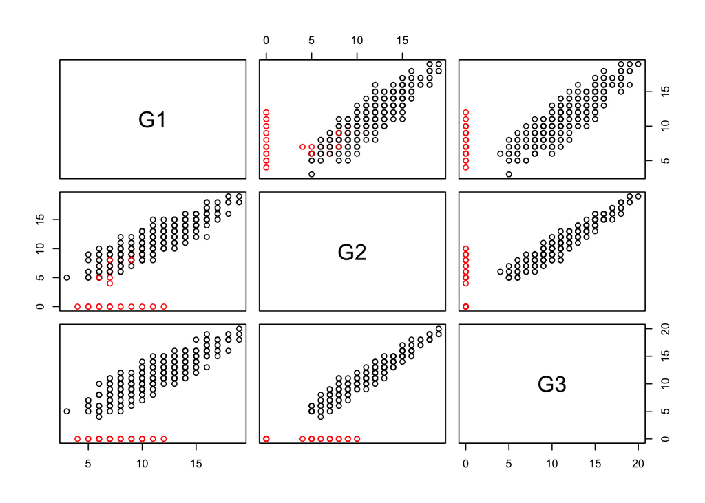

```r
grades = data %>% select(G1,G2,G3)
cols <- character(nrow(grades))
cols[] <- "black"
cols[grades$G3 == 0] <- "red"
pairs(grades,col=cols)
```

```r
cor(grades)
```

```
##           G1        G2        G3
## G1 1.0000000 0.8521181 0.8014679
## G2 0.8521181 1.0000000 0.9048680
## G3 0.8014679 0.9048680 1.0000000
```